# EDA PROJECT FINAL

### Business Problem

Hemanth is a working professional who wants to buy a new air conditioner. He visits multiple online platforms and sees hundreds of AC models with different:

- Prices
- AC capacity options (Ton)
- Energy star ratings
- Brand variations
- Customer ratings

Some ACs cost ₹20,000, while others cost ₹80,000, but many of them appear to have similar features.

Hemanth starts asking questions:

- **“Is paying more really worth it?”**
- **“Should I buy 1 Ton, 1.5 Ton or 2 Ton AC?”**
- **“Do higher energy star ratings always mean better customer ratings?”**
- **“Which features actually increase the price?”**

Like Hemanth, many buyers face the same confusion while purchasing an AC online.

### Business Problem Statement

In today’s online market, customers have access to a wide variety of air conditioners from multiple brands, capacities, and energy ratings. While this provides more choices, it also creates confusion because many AC models appear similar in features but differ significantly in price. As a result, buyers like Hemanth struggle to identify which product provides the best value for money and which factors truly influence the final purchase decision.

This project aims to solve this problem by performing Exploratory Data Analysis (EDA) on AC product data containing information such as Brand, Capacity (Ton), Energy Star Rating, Original Price, Discounted Price, Discount Amount, and Customer Ratings. The analysis focuses on understanding the relationship between these variables and the final discounted price, and also evaluates whether customer satisfaction (ratings) is linked with pricing or energy efficiency.

By identifying key patterns and insights, this study helps in:

- Understanding how price varies with capacity, brand, and star rating
- Finding which factors contribute most to higher prices
- Checking whether expensive products are actually better rated
- Highlighting the best value combinations for customers

Ultimately, the objective is to support customers in making smarter AC purchase decisions using data-driven insights.

```python
import pandas as pd
import numpy as np
import seaborn as sns
import matplotlib.pyplot as plt
```

```python
df1 = pd.read_excel(r"C:\Users\heman\Hemanth\AC_H.xlsx")
df1
```

|  | Brand | Year | Tonnage | Rating |
| --- | --- | --- | --- | --- |
| 0 | Daikin | 2025 | 1.5 Ton | 3 Star |
| 1 | Voltas | 2025 | 1.5 Ton | 3 Star |
| 2 | Haier | 2025 | 1 Ton | 3 Star |
| 3 | Godrej | 2025 | 1.5 Ton | 5 Star |
| 4 | ONIDA | 2025 | 2 Ton | 3 Star |
| ... | ... | ... | ... | ... |
| 475 | Samsung | 2021 | 1.5 Ton | 5 Star |
| 476 | LG | 2025 | 1.5 Ton | 3 Star |
| 477 | Voltas | 2025 | 1 Ton | 3 Star |
| 478 | CARRIER | 2020 | 1.5 Ton | 5 Star |
| 479 | Voltas | 2024 | 1.5 Ton | 5 Star |

480 rows × 4 columns

```python
df2 = pd.read_excel(r"C:\Users\heman\Hemanth\ac_data.xlsx")
df2
```

|  | Price | Original_Price | Ratings |
| --- | --- | --- | --- |
| 0 | ₹33,490 | ₹53,830 | 4.2 |
| 1 | ₹35,990 | ₹75,190 | 4.1 |
| 2 | ₹24,990 | ₹50,000 | 4.1 |
| 3 | ₹33,990 | ₹50,600 | 4.0 |
| 4 | ₹19,990 | ₹42,799 | 4.2 |
| ... | ... | ... | ... |
| 451 | ₹80,990 | ₹54,600 | 4.1 |
| 452 | ₹28,999 | ₹56,400 | 4.2 |
| 453 | ₹32,990 | ₹46,999 | 4.2 |
| 454 | ₹25,790 | ₹70,500 | 5.0 |
| 455 | ₹35,180 | ₹45,000 | 3.0 |

456 rows × 3 columns

```python
df_large = df1.reset_index(drop=True)
df_small = df2.reset_index(drop=True)

df = pd.concat(
    [df_small, df_large.iloc[:len(df_small)]],
    axis=1
)
```

```python
df
```

|  | Price | Original_Price | Ratings | Brand | Year | Tonnage | Rating |
| --- | --- | --- | --- | --- | --- | --- | --- |
| 0 | ₹33,490 | ₹53,830 | 4.2 | Daikin | 2025 | 1.5 Ton | 3 Star |
| 1 | ₹35,990 | ₹75,190 | 4.1 | Voltas | 2025 | 1.5 Ton | 3 Star |
| 2 | ₹24,990 | ₹50,000 | 4.1 | Haier | 2025 | 1 Ton | 3 Star |
| 3 | ₹33,990 | ₹50,600 | 4.0 | Godrej | 2025 | 1.5 Ton | 5 Star |
| 4 | ₹19,990 | ₹42,799 | 4.2 | ONIDA | 2025 | 2 Ton | 3 Star |
| ... | ... | ... | ... | ... | ... | ... | ... |
| 451 | ₹80,990 | ₹54,600 | 4.1 | Daikin | 2025 | 1.5 Ton | 5 Star |
| 452 | ₹28,999 | ₹56,400 | 4.2 | Hitachi | 2023 | 1 Ton | 3 Star |
| 453 | ₹32,990 | ₹46,999 | 4.2 | BLACK | 2024 | 2 Ton | 3 Star |
| 454 | ₹25,790 | ₹70,500 | 5.0 | Whirlpool | 2025 | 1.5 Ton | 3 Star |
| 455 | ₹35,180 | ₹45,000 | 3.0 | Lloyd | 2021 | 1.5 Ton | 3 Star |

456 rows × 7 columns

```python
df.head()
```

|  | Price | Original_Price | Ratings | Brand | Year | Tonnage | Rating |
| --- | --- | --- | --- | --- | --- | --- | --- |
| 0 | ₹33,490 | ₹53,830 | 4.2 | Daikin | 2025 | 1.5 Ton | 3 Star |
| 1 | ₹35,990 | ₹75,190 | 4.1 | Voltas | 2025 | 1.5 Ton | 3 Star |
| 2 | ₹24,990 | ₹50,000 | 4.1 | Haier | 2025 | 1 Ton | 3 Star |
| 3 | ₹33,990 | ₹50,600 | 4.0 | Godrej | 2025 | 1.5 Ton | 5 Star |
| 4 | ₹19,990 | ₹42,799 | 4.2 | ONIDA | 2025 | 2 Ton | 3 Star |

## Data Cleaning

```python
df["Year"] = df["Year"].astype("Int64")
```

```python
df
```

|  | Price | Original_Price | Ratings | Brand | Year | Tonnage | Rating |
| --- | --- | --- | --- | --- | --- | --- | --- |
| 0 | ₹33,490 | ₹53,830 | 4.2 | Daikin | 2025 | 1.5 Ton | 3 Star |
| 1 | ₹35,990 | ₹75,190 | 4.1 | Voltas | 2025 | 1.5 Ton | 3 Star |
| 2 | ₹24,990 | ₹50,000 | 4.1 | Haier | 2025 | 1 Ton | 3 Star |
| 3 | ₹33,990 | ₹50,600 | 4.0 | Godrej | 2025 | 1.5 Ton | 5 Star |
| 4 | ₹19,990 | ₹42,799 | 4.2 | ONIDA | 2025 | 2 Ton | 3 Star |
| ... | ... | ... | ... | ... | ... | ... | ... |
| 451 | ₹80,990 | ₹54,600 | 4.1 | Daikin | 2025 | 1.5 Ton | 5 Star |
| 452 | ₹28,999 | ₹56,400 | 4.2 | Hitachi | 2023 | 1 Ton | 3 Star |
| 453 | ₹32,990 | ₹46,999 | 4.2 | BLACK | 2024 | 2 Ton | 3 Star |
| 454 | ₹25,790 | ₹70,500 | 5.0 | Whirlpool | 2025 | 1.5 Ton | 3 Star |
| 455 | ₹35,180 | ₹45,000 | 3.0 | Lloyd | 2021 | 1.5 Ton | 3 Star |

456 rows × 7 columns

```python
df = df.rename(columns={"Rating": "Star_count"})
df
```

|  | Price | Original_Price | Ratings | Brand | Year | Tonnage | Star_count |
| --- | --- | --- | --- | --- | --- | --- | --- |
| 0 | ₹33,490 | ₹53,830 | 4.2 | Daikin | 2025 | 1.5 Ton | 3 Star |
| 1 | ₹35,990 | ₹75,190 | 4.1 | Voltas | 2025 | 1.5 Ton | 3 Star |
| 2 | ₹24,990 | ₹50,000 | 4.1 | Haier | 2025 | 1 Ton | 3 Star |
| 3 | ₹33,990 | ₹50,600 | 4.0 | Godrej | 2025 | 1.5 Ton | 5 Star |
| 4 | ₹19,990 | ₹42,799 | 4.2 | ONIDA | 2025 | 2 Ton | 3 Star |
| ... | ... | ... | ... | ... | ... | ... | ... |
| 451 | ₹80,990 | ₹54,600 | 4.1 | Daikin | 2025 | 1.5 Ton | 5 Star |
| 452 | ₹28,999 | ₹56,400 | 4.2 | Hitachi | 2023 | 1 Ton | 3 Star |
| 453 | ₹32,990 | ₹46,999 | 4.2 | BLACK | 2024 | 2 Ton | 3 Star |
| 454 | ₹25,790 | ₹70,500 | 5.0 | Whirlpool | 2025 | 1.5 Ton | 3 Star |
| 455 | ₹35,180 | ₹45,000 | 3.0 | Lloyd | 2021 | 1.5 Ton | 3 Star |

456 rows × 7 columns

```python
df = df.rename(columns={"Tonnage": "Capacity"})
df
```

|  | Price | Original_Price | Ratings | Brand | Year | Capacity | Star_count |
| --- | --- | --- | --- | --- | --- | --- | --- |
| 0 | ₹33,490 | ₹53,830 | 4.2 | Daikin | 2025 | 1.5 Ton | 3 Star |
| 1 | ₹35,990 | ₹75,190 | 4.1 | Voltas | 2025 | 1.5 Ton | 3 Star |
| 2 | ₹24,990 | ₹50,000 | 4.1 | Haier | 2025 | 1 Ton | 3 Star |
| 3 | ₹33,990 | ₹50,600 | 4.0 | Godrej | 2025 | 1.5 Ton | 5 Star |
| 4 | ₹19,990 | ₹42,799 | 4.2 | ONIDA | 2025 | 2 Ton | 3 Star |
| ... | ... | ... | ... | ... | ... | ... | ... |
| 451 | ₹80,990 | ₹54,600 | 4.1 | Daikin | 2025 | 1.5 Ton | 5 Star |
| 452 | ₹28,999 | ₹56,400 | 4.2 | Hitachi | 2023 | 1 Ton | 3 Star |
| 453 | ₹32,990 | ₹46,999 | 4.2 | BLACK | 2024 | 2 Ton | 3 Star |
| 454 | ₹25,790 | ₹70,500 | 5.0 | Whirlpool | 2025 | 1.5 Ton | 3 Star |
| 455 | ₹35,180 | ₹45,000 | 3.0 | Lloyd | 2021 | 1.5 Ton | 3 Star |

456 rows × 7 columns

```python
df = df.rename(columns={"Price": "Discounted_price"})
df
```

|  | Discounted_price | Original_Price | Ratings | Brand | Year | Capacity | Star_count |
| --- | --- | --- | --- | --- | --- | --- | --- |
| 0 | ₹33,490 | ₹53,830 | 4.2 | Daikin | 2025 | 1.5 Ton | 3 Star |
| 1 | ₹35,990 | ₹75,190 | 4.1 | Voltas | 2025 | 1.5 Ton | 3 Star |
| 2 | ₹24,990 | ₹50,000 | 4.1 | Haier | 2025 | 1 Ton | 3 Star |
| 3 | ₹33,990 | ₹50,600 | 4.0 | Godrej | 2025 | 1.5 Ton | 5 Star |
| 4 | ₹19,990 | ₹42,799 | 4.2 | ONIDA | 2025 | 2 Ton | 3 Star |
| ... | ... | ... | ... | ... | ... | ... | ... |
| 451 | ₹80,990 | ₹54,600 | 4.1 | Daikin | 2025 | 1.5 Ton | 5 Star |
| 452 | ₹28,999 | ₹56,400 | 4.2 | Hitachi | 2023 | 1 Ton | 3 Star |
| 453 | ₹32,990 | ₹46,999 | 4.2 | BLACK | 2024 | 2 Ton | 3 Star |
| 454 | ₹25,790 | ₹70,500 | 5.0 | Whirlpool | 2025 | 1.5 Ton | 3 Star |
| 455 | ₹35,180 | ₹45,000 | 3.0 | Lloyd | 2021 | 1.5 Ton | 3 Star |

456 rows × 7 columns

```python
df = df.rename(columns={"Star_count": "Star_Count"})
df
```

|  | Discounted_price | Original_Price | Ratings | Brand | Year | Capacity | Star_Count |
| --- | --- | --- | --- | --- | --- | --- | --- |
| 0 | ₹33,490 | ₹53,830 | 4.2 | Daikin | 2025 | 1.5 Ton | 3 Star |
| 1 | ₹35,990 | ₹75,190 | 4.1 | Voltas | 2025 | 1.5 Ton | 3 Star |
| 2 | ₹24,990 | ₹50,000 | 4.1 | Haier | 2025 | 1 Ton | 3 Star |
| 3 | ₹33,990 | ₹50,600 | 4.0 | Godrej | 2025 | 1.5 Ton | 5 Star |
| 4 | ₹19,990 | ₹42,799 | 4.2 | ONIDA | 2025 | 2 Ton | 3 Star |
| ... | ... | ... | ... | ... | ... | ... | ... |
| 451 | ₹80,990 | ₹54,600 | 4.1 | Daikin | 2025 | 1.5 Ton | 5 Star |
| 452 | ₹28,999 | ₹56,400 | 4.2 | Hitachi | 2023 | 1 Ton | 3 Star |
| 453 | ₹32,990 | ₹46,999 | 4.2 | BLACK | 2024 | 2 Ton | 3 Star |
| 454 | ₹25,790 | ₹70,500 | 5.0 | Whirlpool | 2025 | 1.5 Ton | 3 Star |
| 455 | ₹35,180 | ₹45,000 | 3.0 | Lloyd | 2021 | 1.5 Ton | 3 Star |

456 rows × 7 columns

```python
df = df.rename(columns={"Discounted_price": "Discounted_Price"})
df
```

|  | Discounted_Price | Original_Price | Ratings | Brand | Year | Capacity | Star_Count |
| --- | --- | --- | --- | --- | --- | --- | --- |
| 0 | ₹33,490 | ₹53,830 | 4.2 | Daikin | 2025 | 1.5 Ton | 3 Star |
| 1 | ₹35,990 | ₹75,190 | 4.1 | Voltas | 2025 | 1.5 Ton | 3 Star |
| 2 | ₹24,990 | ₹50,000 | 4.1 | Haier | 2025 | 1 Ton | 3 Star |
| 3 | ₹33,990 | ₹50,600 | 4.0 | Godrej | 2025 | 1.5 Ton | 5 Star |
| 4 | ₹19,990 | ₹42,799 | 4.2 | ONIDA | 2025 | 2 Ton | 3 Star |
| ... | ... | ... | ... | ... | ... | ... | ... |
| 451 | ₹80,990 | ₹54,600 | 4.1 | Daikin | 2025 | 1.5 Ton | 5 Star |
| 452 | ₹28,999 | ₹56,400 | 4.2 | Hitachi | 2023 | 1 Ton | 3 Star |
| 453 | ₹32,990 | ₹46,999 | 4.2 | BLACK | 2024 | 2 Ton | 3 Star |
| 454 | ₹25,790 | ₹70,500 | 5.0 | Whirlpool | 2025 | 1.5 Ton | 3 Star |
| 455 | ₹35,180 | ₹45,000 | 3.0 | Lloyd | 2021 | 1.5 Ton | 3 Star |

456 rows × 7 columns

```python
df["Original_Price"] = (
    df["Original_Price"]
    .str.replace("₹", "", regex=False)
    .str.replace(",", "", regex=False)
    .astype(float)
)

df["Original_Price"].mean()
```

```
np.float64(56756.87280701754)
```

```python
df
```

|  | Discounted_Price | Original_Price | Ratings | Brand | Year | Capacity | Star_Count |
| --- | --- | --- | --- | --- | --- | --- | --- |
| 0 | ₹33,490 | 53830.0 | 4.2 | Daikin | 2025 | 1.5 Ton | 3 Star |
| 1 | ₹35,990 | 75190.0 | 4.1 | Voltas | 2025 | 1.5 Ton | 3 Star |
| 2 | ₹24,990 | 50000.0 | 4.1 | Haier | 2025 | 1 Ton | 3 Star |
| 3 | ₹33,990 | 50600.0 | 4.0 | Godrej | 2025 | 1.5 Ton | 5 Star |
| 4 | ₹19,990 | 42799.0 | 4.2 | ONIDA | 2025 | 2 Ton | 3 Star |
| ... | ... | ... | ... | ... | ... | ... | ... |
| 451 | ₹80,990 | 54600.0 | 4.1 | Daikin | 2025 | 1.5 Ton | 5 Star |
| 452 | ₹28,999 | 56400.0 | 4.2 | Hitachi | 2023 | 1 Ton | 3 Star |
| 453 | ₹32,990 | 46999.0 | 4.2 | BLACK | 2024 | 2 Ton | 3 Star |
| 454 | ₹25,790 | 70500.0 | 5.0 | Whirlpool | 2025 | 1.5 Ton | 3 Star |
| 455 | ₹35,180 | 45000.0 | 3.0 | Lloyd | 2021 | 1.5 Ton | 3 Star |

456 rows × 7 columns

```python
df.info()
```

```
<class 'pandas.core.frame.DataFrame'>
RangeIndex: 456 entries, 0 to 455
Data columns (total 7 columns):
 #   Column            Non-Null Count  Dtype
---  ------            --------------  -----
 0   Discounted_Price  456 non-null    object
 1   Original_Price    456 non-null    float64
 2   Ratings           456 non-null    float64
 3   Brand             456 non-null    object
 4   Year              456 non-null    Int64
 5   Capacity          454 non-null    object
 6   Star_Count        453 non-null    object
dtypes: Int64(1), float64(2), object(4)
memory usage: 25.5+ KB
```

```python
df.isna().sum()
```

```
Discounted_Price    0
Original_Price      0
Ratings             0
Brand               0
Year                0
Capacity            2
Star_Count          3
dtype: int64
```

```python
df
```

|  | Discounted_Price | Original_Price | Ratings | Brand | Year | Capacity | Star_Count |
| --- | --- | --- | --- | --- | --- | --- | --- |
| 0 | ₹33,490 | 53830.0 | 4.2 | Daikin | 2025 | 1.5 Ton | 3 Star |
| 1 | ₹35,990 | 75190.0 | 4.1 | Voltas | 2025 | 1.5 Ton | 3 Star |
| 2 | ₹24,990 | 50000.0 | 4.1 | Haier | 2025 | 1 Ton | 3 Star |
| 3 | ₹33,990 | 50600.0 | 4.0 | Godrej | 2025 | 1.5 Ton | 5 Star |
| 4 | ₹19,990 | 42799.0 | 4.2 | ONIDA | 2025 | 2 Ton | 3 Star |
| ... | ... | ... | ... | ... | ... | ... | ... |
| 451 | ₹80,990 | 54600.0 | 4.1 | Daikin | 2025 | 1.5 Ton | 5 Star |
| 452 | ₹28,999 | 56400.0 | 4.2 | Hitachi | 2023 | 1 Ton | 3 Star |
| 453 | ₹32,990 | 46999.0 | 4.2 | BLACK | 2024 | 2 Ton | 3 Star |
| 454 | ₹25,790 | 70500.0 | 5.0 | Whirlpool | 2025 | 1.5 Ton | 3 Star |
| 455 | ₹35,180 | 45000.0 | 3.0 | Lloyd | 2021 | 1.5 Ton | 3 Star |

456 rows × 7 columns

```python
df.info()
```

```
<class 'pandas.core.frame.DataFrame'>
RangeIndex: 456 entries, 0 to 455
Data columns (total 7 columns):
 #   Column            Non-Null Count  Dtype
---  ------            --------------  -----
 0   Discounted_Price  456 non-null    object
 1   Original_Price    456 non-null    float64
 2   Ratings           456 non-null    float64
 3   Brand             456 non-null    object
 4   Year              456 non-null    Int64
 5   Capacity          454 non-null    object
 6   Star_Count        453 non-null    object
dtypes: Int64(1), float64(2), object(4)
memory usage: 25.5+ KB
```

```python
df
```

|  | Discounted_Price | Original_Price | Ratings | Brand | Year | Capacity | Star_Count |
| --- | --- | --- | --- | --- | --- | --- | --- |
| 0 | ₹33,490 | 53830.0 | 4.2 | Daikin | 2025 | 1.5 Ton | 3 Star |
| 1 | ₹35,990 | 75190.0 | 4.1 | Voltas | 2025 | 1.5 Ton | 3 Star |
| 2 | ₹24,990 | 50000.0 | 4.1 | Haier | 2025 | 1 Ton | 3 Star |
| 3 | ₹33,990 | 50600.0 | 4.0 | Godrej | 2025 | 1.5 Ton | 5 Star |
| 4 | ₹19,990 | 42799.0 | 4.2 | ONIDA | 2025 | 2 Ton | 3 Star |
| ... | ... | ... | ... | ... | ... | ... | ... |
| 451 | ₹80,990 | 54600.0 | 4.1 | Daikin | 2025 | 1.5 Ton | 5 Star |
| 452 | ₹28,999 | 56400.0 | 4.2 | Hitachi | 2023 | 1 Ton | 3 Star |
| 453 | ₹32,990 | 46999.0 | 4.2 | BLACK | 2024 | 2 Ton | 3 Star |
| 454 | ₹25,790 | 70500.0 | 5.0 | Whirlpool | 2025 | 1.5 Ton | 3 Star |
| 455 | ₹35,180 | 45000.0 | 3.0 | Lloyd | 2021 | 1.5 Ton | 3 Star |

456 rows × 7 columns

```python
df.describe()
```

|  | Original_Price | Ratings | Year |
| --- | --- | --- | --- |
| count | 456.000000 | 456.000000 | 456.0 |
| mean | 56756.872807 | 4.174342 | 2024.381579 |
| std | 13073.811048 | 0.450957 | 1.109009 |
| min | 30990.000000 | 1.000000 | 2018.0 |
| 25% | 45099.000000 | 4.100000 | 2024.0 |
| 50% | 55500.000000 | 4.200000 | 2025.0 |
| 75% | 67221.500000 | 4.200000 | 2025.0 |
| max | 95990.000000 | 5.000000 | 2026.0 |

```python
df = df.loc[:, ~df.columns.duplicated()]

cols = [col for col in df.columns if col != 'Ratings'] + ['Ratings']
df = df[cols]
```

```python
df
```

[output not shown]

```python
df.to_csv("AC_PROJECT", index=False)
df.to_excel("AC_PROJECT.xlsx", index=False)
```

```python
df
```

|  | Brand | Year | Capacity | Star_Count | Original_Price | Discounted_Price | Ratings |
| --- | --- | --- | --- | --- | --- | --- | --- |
| 0 | Daikin | 2025 | 1.5 Ton | 3 Star | 53830.0 | ₹33,490 | 4.2 |
| 1 | Voltas | 2025 | 1.5 Ton | 3 Star | 75190.0 | ₹35,990 | 4.1 |
| 2 | Haier | 2025 | 1 Ton | 3 Star | 50000.0 | ₹24,990 | 4.1 |
| 3 | Godrej | 2025 | 1.5 Ton | 5 Star | 50600.0 | ₹33,990 | 4.0 |
| 4 | ONIDA | 2025 | 2 Ton | 3 Star | 42799.0 | ₹19,990 | 4.2 |
| ... | ... | ... | ... | ... | ... | ... | ... |
| 451 | Daikin | 2025 | 1.5 Ton | 5 Star | 54600.0 | ₹80,990 | 4.1 |
| 452 | Hitachi | 2023 | 1 Ton | 3 Star | 56400.0 | ₹28,999 | 4.2 |
| 453 | BLACK | 2024 | 2 Ton | 3 Star | 46999.0 | ₹32,990 | 4.2 |
| 454 | Whirlpool | 2025 | 1.5 Ton | 3 Star | 70500.0 | ₹25,790 | 5.0 |
| 455 | Lloyd | 2021 | 1.5 Ton | 3 Star | 45000.0 | ₹35,180 | 3.0 |

456 rows × 7 columns

```python
import pandas as pd
```

```python
df = pd.read_excel(r"C:\Users\heman\Hemanth\AC_PROJECT.xlsx")
df
```

|  | Brand | Year | Capacity | Star_Count | Original_Price | Discounted_Price | Ratings |
| --- | --- | --- | --- | --- | --- | --- | --- |
| 0 | Daikin | 2025 | 1.5 Ton | 3 Star | 53830 | ₹33,490 | 4.2 |
| 1 | Voltas | 2025 | 1.5 Ton | 3 Star | 75190 | ₹35,990 | 4.1 |
| 2 | Haier | 2025 | 1 Ton | 3 Star | 50000 | ₹24,990 | 4.1 |
| 3 | Godrej | 2025 | 1.5 Ton | 5 Star | 50600 | ₹33,990 | 4.0 |
| 4 | ONIDA | 2025 | 2 Ton | 3 Star | 42799 | ₹19,990 | 4.2 |
| ... | ... | ... | ... | ... | ... | ... | ... |
| 451 | Daikin | 2025 | 1.5 Ton | 5 Star | 54600 | ₹80,990 | 4.1 |
| 452 | Hitachi | 2023 | 1 Ton | 3 Star | 56400 | ₹28,999 | 4.2 |
| 453 | BLACK | 2024 | 2 Ton | 3 Star | 46999 | ₹32,990 | 4.2 |
| 454 | Whirlpool | 2025 | 1.5 Ton | 3 Star | 70500 | ₹25,790 | 5.0 |
| 455 | Lloyd | 2021 | 1.5 Ton | 3 Star | 45000 | ₹35,180 | 3.0 |

456 rows × 7 columns

```python
df
```

[output not shown]

```python
df["Discount_Amount"] = df["Original_Price"] - df["Discounted_Price"]
```

```python
df
```

|  | Brand | Year | Capacity | Star_Count | Original_Price | Discounted_Price | Ratings | Discount_Amount |
| --- | --- | --- | --- | --- | --- | --- | --- | --- |
| 0 | Daikin | 2025 | 1.5 Ton | 3 Star | 53830 | 33490.0 | 4.2 | 20340.0 |
| 1 | Voltas | 2025 | 1.5 Ton | 3 Star | 75190 | 35990.0 | 4.1 | 39200.0 |
| 2 | Haier | 2025 | 1 Ton | 3 Star | 50000 | 24990.0 | 4.1 | 25010.0 |
| 3 | Godrej | 2025 | 1.5 Ton | 5 Star | 50600 | 33990.0 | 4.0 | 16610.0 |
| 4 | ONIDA | 2025 | 2 Ton | 3 Star | 42799 | 19990.0 | 4.2 | 22809.0 |
| ... | ... | ... | ... | ... | ... | ... | ... | ... |
| 451 | Daikin | 2025 | 1.5 Ton | 5 Star | 54600 | 80990.0 | 4.1 | -26390.0 |
| 452 | Hitachi | 2023 | 1 Ton | 3 Star | 56400 | 28999.0 | 4.2 | 27401.0 |
| 453 | BLACK | 2024 | 2 Ton | 3 Star | 46999 | 32990.0 | 4.2 | 14009.0 |
| 454 | Whirlpool | 2025 | 1.5 Ton | 3 Star | 70500 | 25790.0 | 5.0 | 44710.0 |
| 455 | Lloyd | 2021 | 1.5 Ton | 3 Star | 45000 | 35180.0 | 3.0 | 9820.0 |

456 rows × 8 columns

```python
df["Price_Band"] = pd.cut(
    df["Discounted_Price"],
    bins=[0, 25000, 40000, 60000, 100000],
    labels=["Budget", "Mid-Range", "Premium", "Luxury"]
)
```

```python
df.head()
```

[output not shown]

```python
import pandas as pd

df["Capacity"] = (
    df["Capacity"]
    .astype(str)
    .str.extract(r"([\d\.]+)")[0]
)
df["Capacity"] = pd.to_numeric(df["Capacity"], errors="coerce")

df["StarRating"] = (
    df["StarRating"]
    .astype(str)
    .str.extract(r"(\d+)")[0]
)
df["StarRating"] = pd.to_numeric(df["StarRating"], errors="coerce").astype("Int64")

df.info()
```

[output not shown]

```python
df["Rating_Category"] = pd.cut(
    df["Ratings"],
    bins=[0, 3.0, 4.0, 4.5, 5.0],
    labels=["Poor", "Average", "Good", "Excellent"],
    include_lowest=True
)
```

```python
df
```

[output not shown]

```python
df.to_csv('Project_data.csv',index = False)
```

```python
df = pd.read_csv(r'C:\Users\heman\Hemanth\Project_data.csv')
```

```python
df.head()
```

|  | Brand | Year | Capacity | StarRating | OriginalPrice | DiscountedPrice | Ratings | Discount_Amount | Price_Band | Rating_Category |
| --- | --- | --- | --- | --- | --- | --- | --- | --- | --- | --- |
| 0 | Daikin | 2025 | 1.5 | 3.0 | 53830 | 334900 | 4.2 | 20340.0 | Mid-Range | Good |
| 1 | Voltas | 2025 | 1.5 | 3.0 | 75190 | 359900 | 4.1 | 39200.0 | Mid-Range | Good |
| 2 | Haier | 2025 | 1.0 | 3.0 | 50000 | 249900 | 4.1 | 25010.0 | Budget | Good |
| 3 | Godrej | 2025 | 1.5 | 5.0 | 50600 | 339900 | 4.0 | 16610.0 | Mid-Range | Average |
| 4 | ONIDA | 2025 | 2.0 | 3.0 | 42799 | 199900 | 4.2 | 22809.0 | Budget | Good |

```python
df.info()
```

```
<class 'pandas.core.frame.DataFrame'>
RangeIndex: 456 entries, 0 to 455
Data columns (total 10 columns):
 #   Column           Non-Null Count  Dtype
---  ------           --------------  -----
 0   Brand            456 non-null    object
 1   Year             456 non-null    int64
 2   Capacity         454 non-null    float64
 3   StarRating       453 non-null    float64
 4   OriginalPrice    456 non-null    int64
 5   DiscountedPrice  456 non-null    int64
 6   Ratings          456 non-null    float64
 7   Discount_Amount  456 non-null    float64
 8   Price_Band       456 non-null    object
 9   Rating_Category  456 non-null    object
dtypes: float64(4), int64(3), object(3)
memory usage: 35.8+ KB
```

### Data Understanding

#### **Key Columns :**

| Column Name | Description |
| --- | --- |
| Brand | Manufacturer/company of the AC product (e.g., Daikin, Voltas, Haier). |
| Year | Model manufacturing/release year of the AC (e.g., 2025). |
| Capacity | Cooling capacity of the AC unit in tons (e.g., 1.0, 1.5, 2.0). |
| StarRating | Energy efficiency rating based on BEE star rating system (e.g., 3-Star, 5-Star). |
| OriginalPrice | Listed retail price before discounts or offers are applied. |
| DiscountedPrice | Final selling price after discounts/offers applied. |
| Ratings | Customer/user rating score for the AC model (e.g., 4.1, 4.2 out of 5). |
| Discount_Amount | Price difference calculated as OriginalPrice − DiscountedPrice. |
| Price_Band | Categorized price segment such as Budget, Mid-Range, or Premium based on pricing. |
| Rating_Category | Categorized rating band (e.g., Good, Average) based on customer rating thresholds. |

### Univariate Analysis

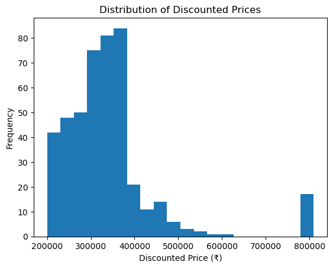

```python
import matplotlib.pyplot as plt

plt.figure()
plt.hist(df['DiscountedPrice'].dropna(), bins=20)
plt.title("Distribution of Discounted Prices")
plt.xlabel("Discounted Price (₹)")
plt.ylabel("Frequency")
plt.show()
```

**Key Insight :**

The distribution is right-skewed, indicating fewer premium models

The market is largely budget-to-mid range focused

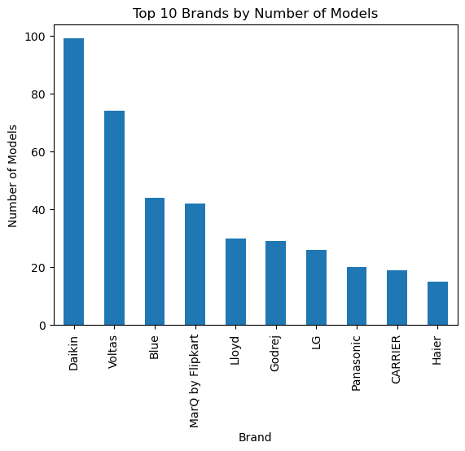

```python
plt.figure()
df["Brand"].value_counts().head(10).plot(kind="bar")
plt.title("Top 10 Brands by Number of Models")
plt.xlabel("Brand")
plt.ylabel("Number of Models")
plt.show()
```

**Key Insight :**

Brands like Daikin and Voltas dominate listings

High model count suggests strong market presence

Smaller brands compete with fewer SKUs

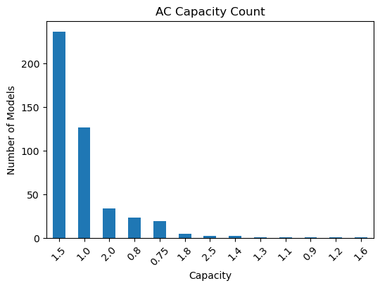

```python
plt.figure(figsize=(6, 4))
df["Capacity"].value_counts().plot(kind="bar")
plt.title("AC Capacity Count")
plt.xlabel("Capacity")
plt.ylabel("Number of Models")
plt.xticks(rotation=45)
plt.show()
```

**Key Insight :**

1.5 Ton ACs dominate the dataset, indicating the highest demand for medium-sized room cooling

1 Ton models are the second most common, preferred for smaller rooms

Higher and uncommon capacities appear far less frequently, suggesting niche market demand

Overall capacity distribution reflects typical residential usage patterns

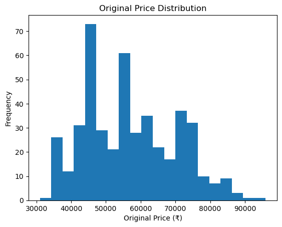

```python
plt.figure()
plt.hist(df["OriginalPrice"].dropna(), bins=20)
plt.title("Original Price Distribution")
plt.xlabel("Original Price (₹)")
plt.ylabel("Frequency")
plt.show()
```

**Key Insight :**

Original prices are spread across a wider range

Peaks around ₹45k–₹60k

Highlights the role of heavy discounting strategies

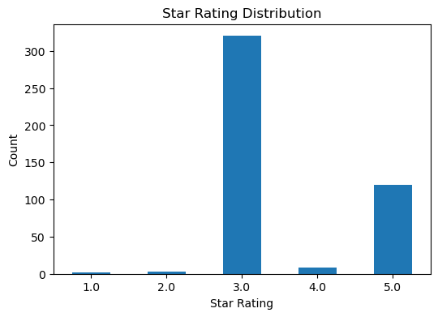

```python
star_order = [1.0, 2.0, 3.0, 4.0, 5.0]

plt.figure(figsize=(6,4))
df["StarRating"].value_counts().reindex(star_order).plot(kind="bar")
plt.title("Star Rating Distribution")
plt.xlabel("Star Rating")
plt.ylabel("Count")
plt.xticks(rotation=0)
plt.show()
```

**Key Insight :**

3-star ACs dominate the market

Energy efficiency is not the top priority for most buyers

Cost likely outweighs long-term power savings

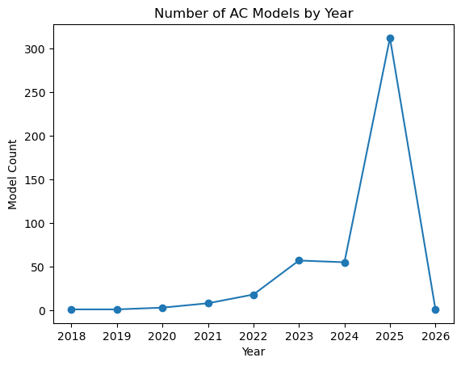

```python
plt.figure()
df["Year"].value_counts().sort_index().plot(kind="line", marker="o")
plt.title("Number of AC Models by Year")
plt.xlabel("Year")
plt.ylabel("Model Count")
plt.show()
```

**Key Insight :**

Sharp spike in 2025 model launches

Indicates rapid innovation and competition

Older models are quickly being phased out

### Bi variate Analysis

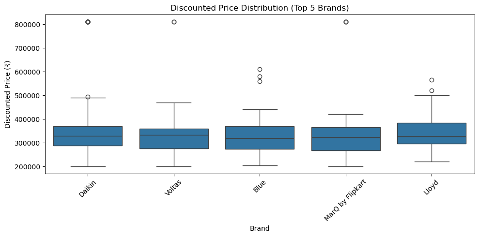

```python
top5_brands = df["Brand"].value_counts().head(5).index

df_top5 = df[df["Brand"].isin(top5_brands)]

plt.figure(figsize=(10,5))
sns.boxplot(x="Brand", y="DiscountedPrice", data=df_top5, order=top5_brands)
plt.title("Discounted Price Distribution (Top 5 Brands)")
plt.xlabel("Brand")
plt.ylabel("Discounted Price (₹)")
plt.xticks(rotation=45)
plt.tight_layout()
plt.show()
```

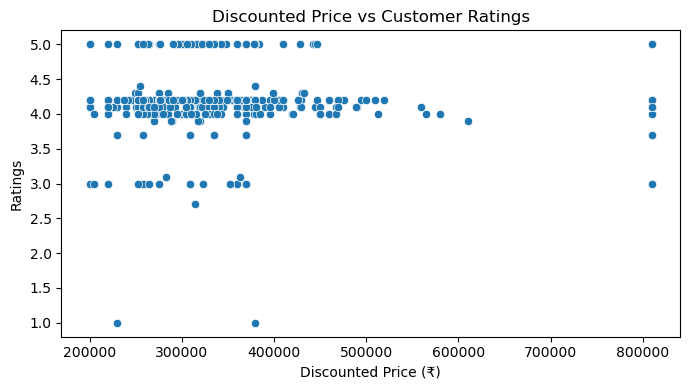

```python
plt.figure(figsize=(7,4))
sns.scatterplot(x="DiscountedPrice", y="Ratings", data=df)
plt.title("Discounted Price vs Customer Ratings")
plt.xlabel("Discounted Price (₹)")
plt.ylabel("Ratings")
plt.tight_layout()
plt.show()
```

**key insight :**

- Customer ratings stay mostly between 4.0–4.5 across all price ranges, showing consistent satisfaction.
- There is no clear relationship between discounted price and ratings, meaning higher price does not guarantee higher rating.

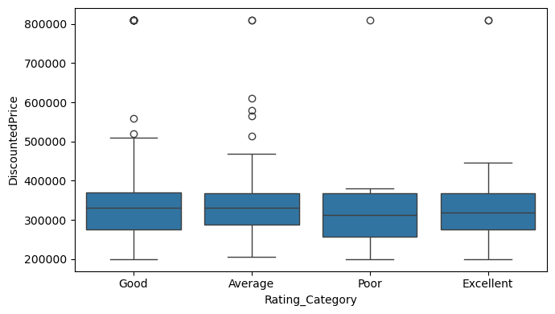

```python
plt.figure(figsize=(7,4))
sns.boxplot(x="Rating_Category", y="DiscountedPrice", data=df)
plt.tight_layout()
plt.show()
```

**Key Insights:**

- Median discounted prices are very similar across all rating categories, showing that price does not strongly depend on customer rating category.
- Each category has high-price outliers, indicating a few premium models exist regardless of rating level.

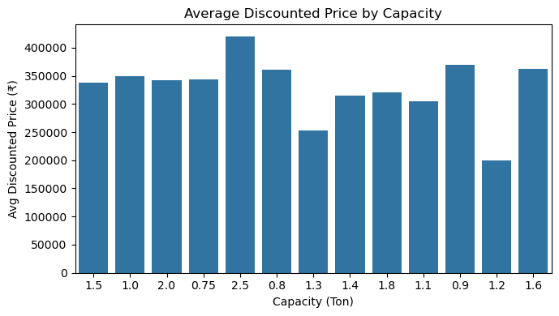

```python
plt.figure(figsize=(7,4))

df_cap = df.dropna(subset=["Capacity"])

sns.barplot(
    x=df_cap["Capacity"].astype(str),
    y="DiscountedPrice",
    data=df_cap,
    errorbar=None
)

plt.title("Average Discounted Price by Capacity")
plt.xlabel("Capacity (Ton)")
plt.ylabel("Avg Discounted Price (₹)")
plt.tight_layout()
plt.show()
```

**Key Insight:**

- Average discounted price generally stays similar across most capacities, indicating capacity alone does not strongly affect price.
- Some capacities show higher/lower average prices due to brand/model mix, meaning price is influenced more by brand/features than tonnage.

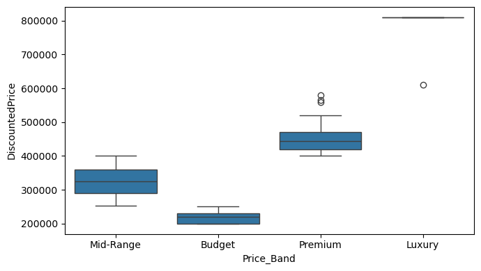

```python
plt.figure(figsize=(7,4))
sns.boxplot(x="Price_Band", y="DiscountedPrice", data=df)
plt.tight_layout()
plt.show()
```

**Key Insights:**

- Clear separation is visible across price bands: Budget has the lowest discounted prices, while Premium and Luxury have much higher prices.
- Luxury band shows very high prices with minimal variation, indicating only a few high-end AC models fall under this category.

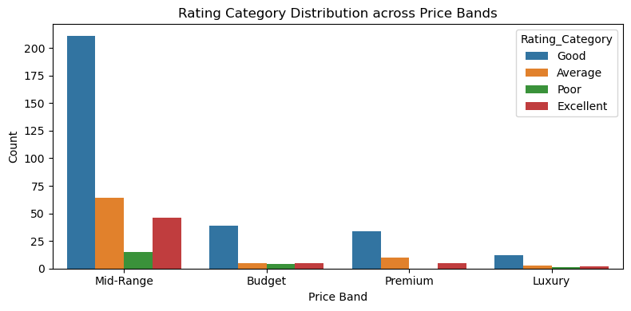

```python
plt.figure(figsize=(8,4))
sns.countplot(x="Price_Band", hue="Rating_Category", data=df)
plt.title("Rating Category Distribution across Price Bands")
plt.xlabel("Price Band")
plt.ylabel("Count")
plt.tight_layout()
plt.show()
```

**Key Insights:**

- Mid-Range ACs dominate the dataset and they mostly fall under the “Good” rating category, indicating most products are reasonably rated.
- Premium and Luxury bands have fewer products, but they still show a mix of rating categories—higher price does not always guarantee “Excellent” ratings.

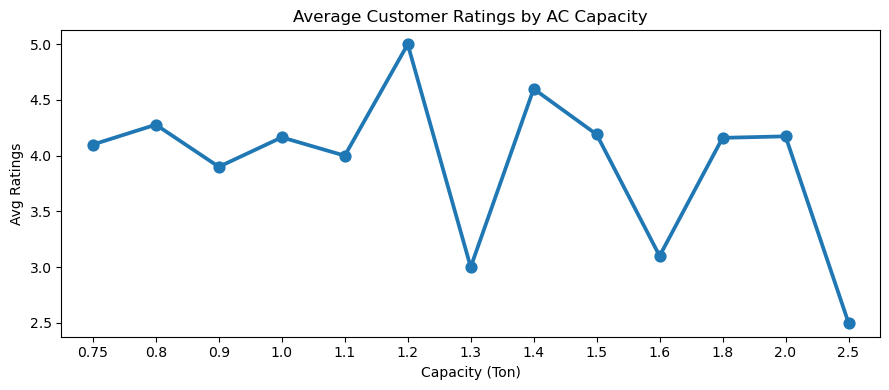

```python
df_cap = df.dropna(subset=["Capacity"])

order = sorted(df_cap["Capacity"].unique())

plt.figure(figsize=(9,4))
sns.pointplot(x="Capacity", y="Ratings", data=df_cap, order=order, errorbar=None)
plt.title("Average Customer Ratings by AC Capacity")
plt.xlabel("Capacity (Ton)")
plt.ylabel("Avg Ratings")
plt.tight_layout()
plt.show()
```

**Key Insights:**

- Customer ratings remain mostly consistent (~4.0+) across common capacities, showing capacity does not strongly affect satisfaction.
- Some rare capacities show sudden spikes/drops in ratings, likely due to fewer models available in those capacities (small sample size effect).

### Outlier Analysis

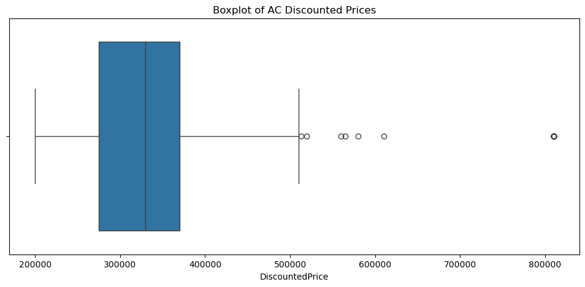

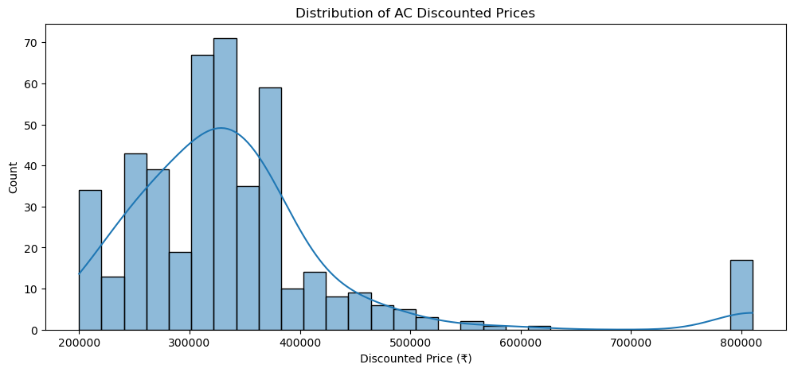

```
Skewness: 2.508514254890013
Kurtosis: 7.940660041606236
Price Percentiles: [199900. 219900. 274900. 329900. 369900. 510600. 809900.]
IQR: 95000.0
Lower Bound: 132400.0
Upper Bound: 512400.0
Outliers Count: 23 (5.04%)
```

```python
import numpy as np
import seaborn as sns
import matplotlib.pyplot as plt


plt.figure(figsize=(12,5))
sns.boxplot(data=df, x="DiscountedPrice")
plt.title("Boxplot of AC Discounted Prices")
plt.show()


plt.figure(figsize=(12,5))
sns.histplot(df["DiscountedPrice"], kde=True, bins=30)
plt.title("Distribution of AC Discounted Prices")
plt.xlabel("Discounted Price (₹)")
plt.ylabel("Count")
plt.show()


print("Skewness:", df["DiscountedPrice"].skew())
print("Kurtosis:", df["DiscountedPrice"].kurt())


percentiles = np.percentile(df["DiscountedPrice"].dropna(), [1,5,25,50,75,95,99])
print("Price Percentiles:", percentiles)


q1 = df["DiscountedPrice"].quantile(0.25)
q3 = df["DiscountedPrice"].quantile(0.75)
iqr = q3 - q1

upper = q3 + 1.5 * iqr
lower = q1 - 1.5 * iqr

print("IQR:", iqr)
print("Lower Bound:", lower)
print("Upper Bound:", upper)

outliers = df[(df["DiscountedPrice"] < lower) | (df["DiscountedPrice"] > upper)]
print(f"Outliers Count: {outliers.shape[0]} ({round(outliers.shape[0]/df.shape[0]*100,2)}%)")
```

### Outlier Conclusion :

**Observation:** AC discounted prices show a right-skewed distribution with a few extreme high-price values. These outliers represent premium / luxury AC models, higher capacity units, or brand-based pricing differences. Since they reflect real market variation and not data entry errors, outliers are retained for business interpretation and further analysis.

```python
import warnings
warnings.filterwarnings('ignore')
```

## Hypothesis Testing

### Hypothesis Test 1 (T-Test)

Do Premium + Luxury ACs have higher discount amounts than Budget + Mid-Range ACs?

**H0 (Null):** Mean discount amount of Budget + Mid-Range ACs = Mean discount amount of Premium + Luxury ACs

**H1 (Alternative):** Mean discount amount of Premium + Luxury ACs > Mean discount amount of Budget + Mid-Range ACs

[output not shown]

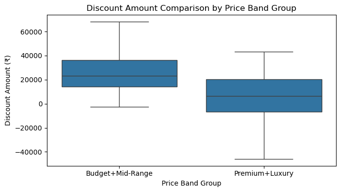

```python
from scipy.stats import ttest_ind

high_band = df[df["Price_Band"].isin(["Premium", "Luxury"])]["Discount_Amount"].dropna()
low_band  = df[df["Price_Band"].isin(["Budget", "Mid-Range"])]["Discount_Amount"].dropna()

t_stat, p_val = ttest_ind(high_band, low_band, equal_var=False)

if p_val < 0.05:
    print("Reject H0 → Premium/Luxury ACs have significantly higher discount amounts.")
else:
    print("Fail to Reject H0 → No significant difference in discount amounts.")



import seaborn as sns
import matplotlib.pyplot as plt

df["Band_Group"] = df["Price_Band"].apply(lambda x: "Premium+Luxury" if x in ["Premium","Luxury"]
                                         else "Budget+Mid-Range")

plt.figure(figsize=(7,4))
sns.boxplot(x="Band_Group", y="Discount_Amount", data=df)
plt.title("Discount Amount Comparison by Price Band Group")
plt.xlabel("Price Band Group")
plt.ylabel("Discount Amount (₹)")
plt.tight_layout()
plt.show()
```

### Key Insight :

- Budget + Mid-Range ACs show higher discount amounts than Premium + Luxury ACs, indicating larger discounts are more common in lower and mid-price segments.
- This suggests that discounts are used as a strategy to boost sales in budget/mid-range categories, while premium models have comparatively smaller discount offers.

### Hypothesis Test 2 (T-Test)

Do Excellent category ACs have higher customer ratings than Average category ACs?

**H0 (Null):** Mean Ratings of Average category ACs = Mean Ratings of Excellent category ACs

**H1 (Alternative):** Mean Ratings of Excellent category ACs > Mean Ratings of Average category ACs

```
Reject H0 → Excellent category has significantly higher ratings than Average.
```

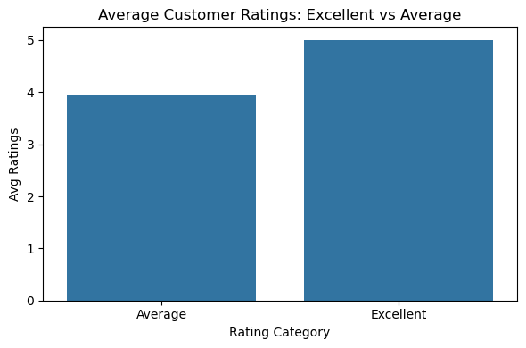

```python
from scipy.stats import ttest_ind

excellent = df[df["Rating_Category"] == "Excellent"]["Ratings"].dropna()
average   = df[df["Rating_Category"] == "Average"]["Ratings"].dropna()

t_stat, p_val = ttest_ind(excellent, average, equal_var=False)

if p_val < 0.05:
    print("Reject H0 → Excellent category has significantly higher ratings than Average.")
else:
    print("Fail to Reject H0 → No significant difference between Excellent and Average ratings.")



plt.figure(figsize=(6,4))
sns.barplot(x="Rating_Category", y="Ratings", data=df, order=["Average", "Excellent"], errorbar=None)
plt.title("Average Customer Ratings: Excellent vs Average")
plt.xlabel("Rating Category")
plt.ylabel("Avg Ratings")
plt.tight_layout()
plt.show()
```

### Key Insight :

- Excellent category ACs have significantly higher customer ratings than Average category ACs (Reject H0).
- This confirms that the Rating_Category classification is meaningful and reflects real differences in customer satisfaction.

### Hypothesis Test 3 (ANOVA)

Does Discounted Price differ significantly across different Energy Star Ratings (1 to 5)?

**H0 (Null):** Mean Discounted Price is same for all Star Ratings (1,2,3,4,5)

**H1 (Alternative):** At least one Star Rating group has a significantly different mean Discounted Price

[output not shown]

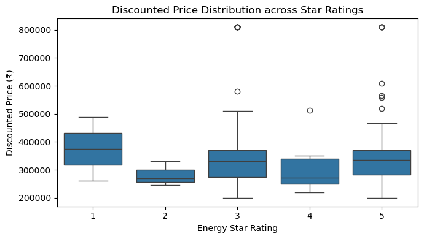

```python
from scipy.stats import f_oneway
import seaborn as sns
import matplotlib.pyplot as plt

df_star = df.dropna(subset=["StarRating", "DiscountedPrice"])

groups = [
    df_star[df_star["StarRating"] == s]["DiscountedPrice"]
    for s in sorted(df_star["StarRating"].unique())
]

f_stat, p_val = f_oneway(*groups)

if p_val < 0.05:
    print("Reject H0 → Discounted prices differ significantly across Star Ratings.")
else:
    print("Fail to Reject H0 → No significant difference in discounted prices across Star Ratings.")

plt.figure(figsize=(7,4))
sns.boxplot(x="StarRating", y="DiscountedPrice", data=df_star, order=[1,2,3,4,5])
plt.title("Discounted Price Distribution across Star Ratings")
plt.xlabel("Energy Star Rating")
plt.ylabel("Discounted Price (₹)")
plt.tight_layout()
plt.show()
```

### Key Insight :

- Discounted Price does not vary significantly across different Energy Star Ratings (1–5) (Fail to Reject H0).
- This indicates that Energy efficiency (Star Rating) is not a major factor affecting discounted price in this dataset, and price is likely influenced more by brand, capacity, and discounts.

# Conclusion:

## **Interpretation**

ACs are not priced randomly. Pricing reflects a combination of:

- brand positioning (premium vs budget brands),
- product segment (Budget/Mid-range/Premium/Luxury),
- discount strategies by sellers,
- capacity requirements,
- market competition and feature differentiation.

## **Business Insight for Hemanth**

Hemanth should not assume that higher-priced ACs are always better.  
Instead, **brand + price band + discount value** matter more than just price alone.

# Bivariate EDA — Key Learnings

### **Discounted Price vs Brand**

Top brands have competitive pricing, but some brands (premium brands) show slightly higher median prices.

**Interpretation:** Brand reputation and model variety influence price.

### **Discounted Price vs Customer Ratings**

Ratings stay mostly around **4.0–4.5** across all price ranges.

**Interpretation:** Higher price does **not guarantee better customer satisfaction**.

### **Discounted Price vs Price Band**

Clear separation exists: **Budget < Mid-range < Premium < Luxury**.

**Interpretation:** Price band strongly explains the price variation.

### **Star Rating vs Discounted Price**

No significant difference in discounted prices across star ratings.

**Interpretation:** Star rating affects electricity savings, but not strongly reflected in discounted price.

# Hypothesis Validation (EDA → Statistics)

EDA suggested patterns. Hypothesis testing confirmed whether they were real:

- **H1 (Price Band vs Discount Amount):** Significant difference (**Reject H0**)
- **H2 (Excellent vs Average Ratings):** Excellent category has significantly higher ratings (**Reject H0**)
- **H3 (Star Rating vs Discounted Price):** No significant difference across star ratings (**Fail to Reject H0**)

## **Interpretation**

What we saw visually was not random — the patterns are statistically valid, and the dataset supports these insights confidently.

# Final Business Insights

**“Is paying more really worth it?”**

- Not always. Higher price does not guarantee higher customer ratings.

**“Which AC should I choose — 1 Ton, 1.5 Ton or 2 Ton?”**

- Capacity should be chosen based on room size, not pricing alone (prices overlap heavily).

**“Do higher star-rated ACs always cost more?”**

- Not necessarily. Star rating does not significantly affect discounted price in this dataset.

**“Which factor impacts price most?”**

- Price Band and Brand influence discounted price more than star rating.

# Final Recommendations

## Final Conclusion:

AC pricing is multi-factor and strategy-driven — choosing the best AC requires balancing **brand, price band, discounts, and ratings** rather than depending only on price.